# Load and getting familiar with NetCDF datasets

Climate Geospatial Analysis on Python with Xarray - Coursera

```python
import xarray as xr
import warnings
warnings.filterwarnings('ignore')
```

```python
ds = xr.open_dataset('data.nc')
```

# Specify plotting parameters

```python
import matplotlib.pyplot as plt
plt.rcParams['figure.figsize'] = [10, 7]
plt.rcParams.update({'font.size': 12})
```

# Print the dataset attributes

```python
ds
```

```
<xarray.Dataset>
Dimensions:    (longitude: 142, latitude: 89, expver: 2, time: 500)
Coordinates:
  * longitude  (longitude) float32 -82.0 -81.75 -81.5 ... -47.25 -47.0 -46.75
  * latitude   (latitude) float32 6.0 5.75 5.5 5.25 ... -15.5 -15.75 -16.0
  * expver     (expver) int32 1 5
  * time       (time) datetime64[ns] 1979-01-01 1979-02-01 ... 2020-08-01
Data variables:
    lai_hv     (time, expver, latitude, longitude) float32 ...
    skt        (time, expver, latitude, longitude) float32 ...
    tp         (time, expver, latitude, longitude) float32 ...
Attributes:
    Conventions:  CF-1.6
    history:      2020-09-30 12:13:58 GMT by grib_to_netcdf-2.16.0: /opt/ecmw...
```

# Basic info about the dataset

expver: 2 mix of ERA5 (level 01) AND ERA5T (level 05)

Time no. steps = 500, from 1979 Jan to 2020 Aug (monthly data)

tp = total precipitation in metres

skt = surface temperature in Kelvin

lai_hv = leaf area index, high vegetation

Latitude is from 6 to -16, resolution = 0.25 degree

Longitude is from -82 to -46.75, resolution = 0.25 degree

# Drop the Longitude attribute (select data having a specific Longitude)

```python
ds.sel(longitude = -82)
```

```
<xarray.Dataset>
Dimensions:    (latitude: 89, expver: 2, time: 500)
Coordinates:
    longitude  float32 -82.0
  * latitude   (latitude) float32 6.0 5.75 5.5 5.25 ... -15.5 -15.75 -16.0
  * expver     (expver) int32 1 5
  * time       (time) datetime64[ns] 1979-01-01 1979-02-01 ... 2020-08-01
Data variables:
    lai_hv     (time, expver, latitude) float32 0.0 0.0 0.0 0.0 ... 0.0 0.0 0.0
    skt        (time, expver, latitude) float32 300.7 300.6 ... 290.4 290.5
    tp         (time, expver, latitude) float32 0.0004338 ... 0.0003513
Attributes:
    Conventions:  CF-1.6
    history:      2020-09-30 12:13:58 GMT by grib_to_netcdf-2.16.0: /opt/ecmw...
```

# Select data having a specific Longitude, latitude and time step

```python
ds.sel(longitude = -82, latitude = 6, time = '2018-01-01')
```

```
<xarray.Dataset>
Dimensions:    (expver: 2)
Coordinates:
    longitude  float32 -82.0
    latitude   float32 6.0
  * expver     (expver) int32 1 5
    time       datetime64[ns] 2018-01-01
Data variables:
    lai_hv     (expver) float32 0.0 nan
    skt        (expver) float32 300.7 nan
    tp         (expver) float32 0.005962 nan
Attributes:
    Conventions:  CF-1.6
    history:      2020-09-30 12:13:58 GMT by grib_to_netcdf-2.16.0: /opt/ecmw...
```

# The method "nearest" can be helpful if there are no values in the points of interest

```python
ds.sel(longitude = -82, latitude = 99, time = '2018-01-01', method = 'nearest')
```

```
<xarray.Dataset>
Dimensions:    (expver: 2)
Coordinates:
    longitude  float32 -82.0
    latitude   float32 6.0
  * expver     (expver) int32 1 5
    time       datetime64[ns] 2018-01-01
Data variables:
    lai_hv     (expver) float32 0.0 nan
    skt        (expver) float32 300.7 nan
    tp         (expver) float32 0.005962 nan
Attributes:
    Conventions:  CF-1.6
    history:      2020-09-30 12:13:58 GMT by grib_to_netcdf-2.16.0: /opt/ecmw...
```

# Select data for multiple points at once (use "nearest" method incase there are no values in the points of interest)

```python
ds.sel(longitude = [-46, -47], latitude = [-16, -15], method = 'nearest')
```

```
<xarray.Dataset>
Dimensions:    (longitude: 2, latitude: 2, expver: 2, time: 500)
Coordinates:
  * longitude  (longitude) float32 -46.75 -47.0
  * latitude   (latitude) float32 -16.0 -15.0
  * expver     (expver) int32 1 5
  * time       (time) datetime64[ns] 1979-01-01 1979-02-01 ... 2020-08-01
Data variables:
    lai_hv     (time, expver, latitude, longitude) float32 1.987 1.963 ... 1.466
    skt        (time, expver, latitude, longitude) float32 295.2 295.3 ... 297.4
    tp         (time, expver, latitude, longitude) float32 0.02018 ... 0.0
Attributes:
    Conventions:  CF-1.6
    history:      2020-09-30 12:13:58 GMT by grib_to_netcdf-2.16.0: /opt/ecmw...
```

# Select data by index

```python
ds.isel(latitude = 0, longitude = 0)
#Here data from the first latitude and longitude is selected
```

```
<xarray.Dataset>
Dimensions:    (expver: 2, time: 500)
Coordinates:
    longitude  float32 -82.0
    latitude   float32 6.0
  * expver     (expver) int32 1 5
  * time       (time) datetime64[ns] 1979-01-01 1979-02-01 ... 2020-08-01
Data variables:
    lai_hv     (time, expver) float32 0.0 nan 0.0 nan 0.0 ... nan 0.0 nan 0.0
    skt        (time, expver) float32 300.7 nan 300.8 nan ... 300.2 nan 300.1
    tp         (time, expver) float32 0.0004338 nan 0.001139 ... nan 0.01796
Attributes:
    Conventions:  CF-1.6
    history:      2020-09-30 12:13:58 GMT by grib_to_netcdf-2.16.0: /opt/ecmw...
```

# Select and Filter data by query

```python
query = ds.longitude < -64
query = query & (ds.latitude >-8)

ds.where(query, drop =True)
```

```
<xarray.Dataset>
Dimensions:    (time: 500, expver: 2, latitude: 56, longitude: 72)
Coordinates:
  * longitude  (longitude) float32 -82.0 -81.75 -81.5 ... -64.75 -64.5 -64.25
  * latitude   (latitude) float32 6.0 5.75 5.5 5.25 ... -7.0 -7.25 -7.5 -7.75
  * expver     (expver) int32 1 5
  * time       (time) datetime64[ns] 1979-01-01 1979-02-01 ... 2020-08-01
Data variables:
    lai_hv     (time, expver, latitude, longitude) float32 0.0 0.0 ... 6.63
    skt        (time, expver, latitude, longitude) float32 300.7 300.6 ... 300.5
    tp         (time, expver, latitude, longitude) float32 0.0004338 ... 0.00...
Attributes:
    Conventions:  CF-1.6
    history:      2020-09-30 12:13:58 GMT by grib_to_netcdf-2.16.0: /opt/ecmw...
```

```python
ds.where(query, drop =True).longitude
```

```
<xarray.DataArray 'longitude' (longitude: 72)>
array([-82.  , -81.75, -81.5 , -81.25, -81.  , -80.75, -80.5 , -80.25, -80.  ,
       -79.75, -79.5 , -79.25, -79.  , -78.75, -78.5 , -78.25, -78.  , -77.75,
       -77.5 , -77.25, -77.  , -76.75, -76.5 , -76.25, -76.  , -75.75, -75.5 ,
       -75.25, -75.  , -74.75, -74.5 , -74.25, -74.  , -73.75, -73.5 , -73.25,
       -73.  , -72.75, -72.5 , -72.25, -72.  , -71.75, -71.5 , -71.25, -71.  ,
       -70.75, -70.5 , -70.25, -70.  , -69.75, -69.5 , -69.25, -69.  , -68.75,
       -68.5 , -68.25, -68.  , -67.75, -67.5 , -67.25, -67.  , -66.75, -66.5 ,
       -66.25, -66.  , -65.75, -65.5 , -65.25, -65.  , -64.75, -64.5 , -64.25],
      dtype=float32)
Coordinates:
  * longitude  (longitude) float32 -82.0 -81.75 -81.5 ... -64.75 -64.5 -64.25
Attributes:
    units:      degrees_east
    long_name:  longitude
```

```python
ds.where(query, drop =True).latitude
```

```
<xarray.DataArray 'latitude' (latitude: 56)>
array([ 6.  ,  5.75,  5.5 ,  5.25,  5.  ,  4.75,  4.5 ,  4.25,  4.  ,  3.75,
        3.5 ,  3.25,  3.  ,  2.75,  2.5 ,  2.25,  2.  ,  1.75,  1.5 ,  1.25,
        1.  ,  0.75,  0.5 ,  0.25,  0.  , -0.25, -0.5 , -0.75, -1.  , -1.25,
       -1.5 , -1.75, -2.  , -2.25, -2.5 , -2.75, -3.  , -3.25, -3.5 , -3.75,
       -4.  , -4.25, -4.5 , -4.75, -5.  , -5.25, -5.5 , -5.75, -6.  , -6.25,
       -6.5 , -6.75, -7.  , -7.25, -7.5 , -7.75], dtype=float32)
Coordinates:
  * latitude  (latitude) float32 6.0 5.75 5.5 5.25 5.0 ... -7.0 -7.25 -7.5 -7.75
Attributes:
    units:      degrees_north
    long_name:  latitude
```

# Plot histogram of surface Temperature

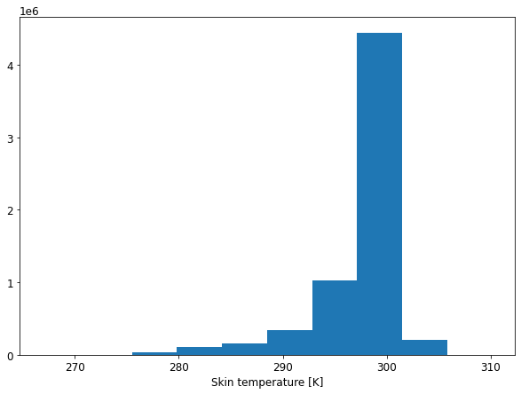

```python
ds.skt.plot()
```

# Plot the data by selecting by index

Here, the first time step, and ERA5 (Level 1) data are selected, the plot shows the spatial distribution of surface temperature of the starting date of the dataset.

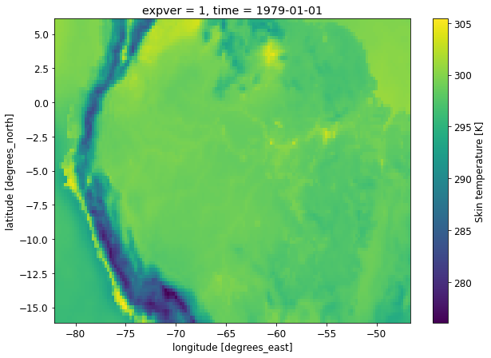

```python
ds.isel(time=0, expver=0).skt.plot()
```

Similary, the map for vegetation density:

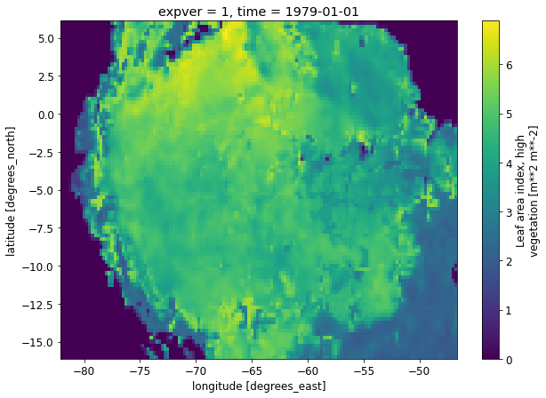

```python
ds.isel(time=0, expver=0).lai_hv.plot()
```

# Obtain Time Series of data for a specific point (selection by index)

Here, the first latitiude and longitude is selected

```python
print(ds.isel(latitude=0, longitude=0, expver = 0))
```

```
<xarray.Dataset>
Dimensions:    (time: 500)
Coordinates:
    longitude  float32 -82.0
    latitude   float32 6.0
    expver     int32 1
  * time       (time) datetime64[ns] 1979-01-01 1979-02-01 ... 2020-08-01
Data variables:
    lai_hv     (time) float32 ...
    skt        (time) float32 ...
    tp         (time) float32 ...
Attributes:
    Conventions:  CF-1.6
    history:      2020-09-30 12:13:58 GMT by grib_to_netcdf-2.16.0: /opt/ecmw...
```

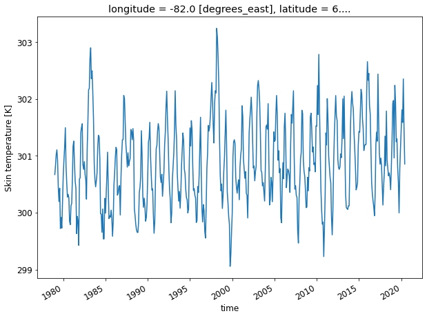

```python
ds.isel(latitude=0, longitude=0, expver = 0).skt.plot()
```

# Obtain variation of surface Temperature for a specific longitude and time step across various latitude

```python
print(ds.sel(time = "2001-09-01", longitude = -59, method ="nearest", expver = 1))
```

```
<xarray.Dataset>
Dimensions:    (latitude: 89)
Coordinates:
    longitude  float32 -59.0
  * latitude   (latitude) float32 6.0 5.75 5.5 5.25 ... -15.5 -15.75 -16.0
    expver     int32 1
    time       datetime64[ns] 2001-09-01
Data variables:
    lai_hv     (latitude) float32 ...
    skt        (latitude) float32 ...
    tp         (latitude) float32 ...
Attributes:
    Conventions:  CF-1.6
    history:      2020-09-30 12:13:58 GMT by grib_to_netcdf-2.16.0: /opt/ecmw...
```

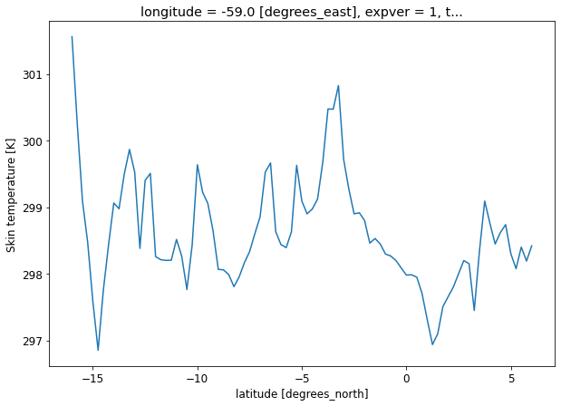

```python
ds.sel(time = "2001-09-01", longitude = -59, method ="nearest", expver = 1).skt.plot()
```

# Analyze the change in Temperature from two different Time steps

```python
temperature_change = ds.sel(time = '2019-01-01',expver = 1).skt - ds.sel(time = '1979-01-01', expver = 1).skt
```

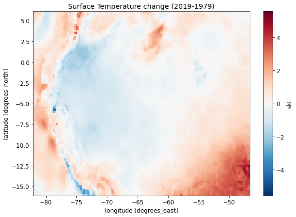

```python
temperature_change.plot()
plt.title("Surface Temperature change (2019-1979)")
```

# Analyze the seasonal change in vegetation from two different Time steps in a single year

```python
seasonal_change_veg = ds.sel(time = '2019-07-01',expver = 1).lai_hv - ds.sel(time = '2019-01-01', expver = 1).lai_hv
```

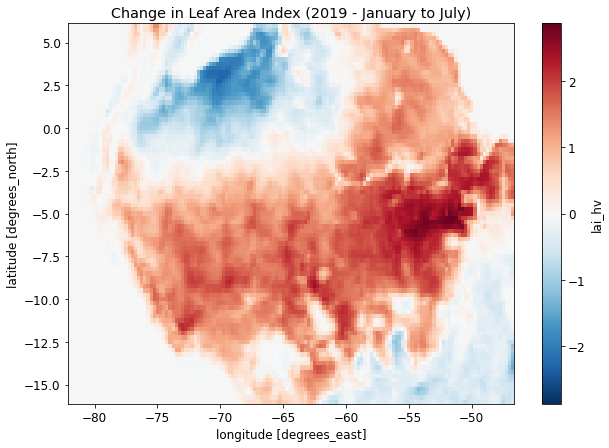

```python
seasonal_change_veg.plot()
plt.title("Change in Leaf Area Index (2019 - January to July)")
```

# Data Aggregation by Mean

Mean Temperature Across all Latitude and Longitude (over the entire time period)

```python
ds_expver_1 = ds.sel(expver = 1)
mean_temperature = ds_expver_1.skt.mean(dim = 'time')
```

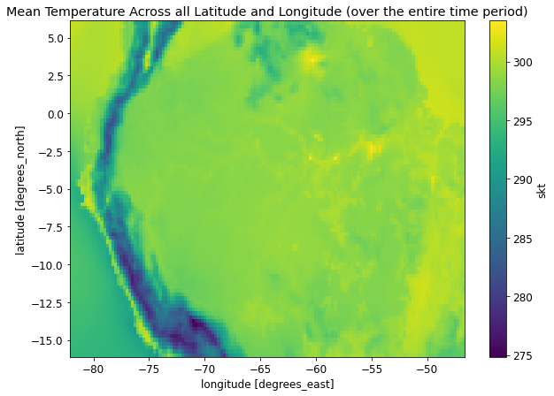

```python
mean_temperature.plot()
plt.title('Mean Temperature Across all Latitude and Longitude (over the entire time period)')
```

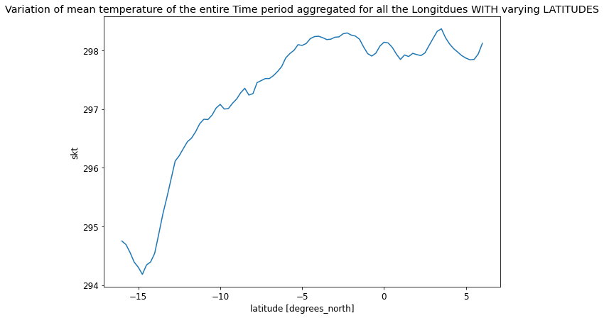

```python
mean_temperature.mean(dim = 'longitude').plot()
plt.title("Variation of mean temperature of the entire Time period aggregated for all the Longitdues WITH varying LATITUDES")
```

# Standard Deviation of Surface Temperature

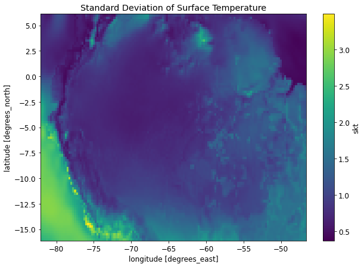

```python
ds_expver_1.skt.std(dim ='time').plot()
plt.title("Standard Deviation of Surface Temperature")
```

# Time Series of Temperature averaged across all Latitudes and Longitudes

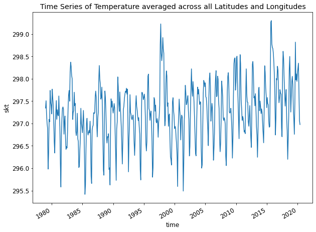

```python
ds_expver_1.skt.mean(dim =['latitude', 'longitude']).plot()
plt.title("Time Series of Temperature averaged across all Latitudes and Longitudes")
```

# Use "groupby" function to get a Time Series of YEARLY AVERAGED surface Temperature values, averaged over all Latitudes and Longitudes

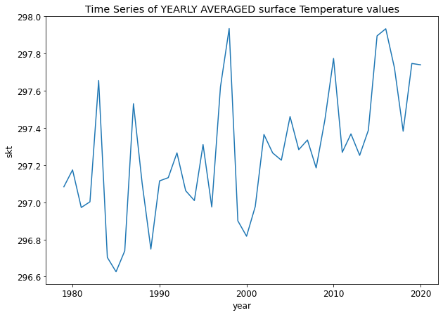

```python
ds_expver_1.groupby(ds_expver_1.time.dt.year).mean(dim = ['latitude', 'longitude', 'time']).skt.plot()
plt.title("Time Series of YEARLY AVERAGED surface Temperature values")
```

# Plot INTER-ANNUAL mean Temperature, averaged over all Latitudes and Longitudes

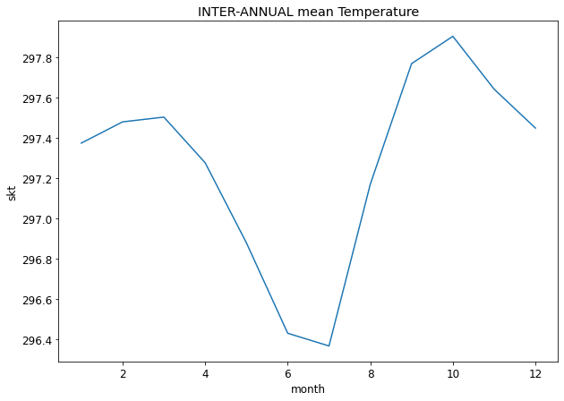

```python
ds_expver_1.groupby(ds_expver_1.time.dt.month).mean(dim = ['latitude', 'longitude', 'time']).skt.plot()
plt.title("INTER-ANNUAL mean Temperature")
```

# Plot INTER-ANNUAL mean Leaf Area Index, averaged over all Latitudes and Longitudes

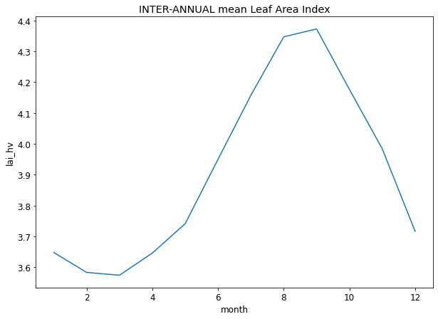

```python
ds_expver_1.groupby(ds_expver_1.time.dt.month).mean(dim = ['latitude', 'longitude', 'time']).lai_hv.plot()
plt.title("INTER-ANNUAL mean Leaf Area Index")
```

# Use "resample" function to visualize data at a "certain year averaged value"

```python
ds_expver_1.resample({'time': '10y'}).mean(dim=['time', 'longitude', 'latitude']).time
```

```
<xarray.DataArray 'time' (time: 6)>
array(['1979-12-31T00:00:00.000000000', '1989-12-31T00:00:00.000000000',
       '1999-12-31T00:00:00.000000000', '2009-12-31T00:00:00.000000000',
       '2019-12-31T00:00:00.000000000', '2029-12-31T00:00:00.000000000'],
      dtype='datetime64[ns]')
Coordinates:
  * time     (time) datetime64[ns] 1979-12-31 1989-12-31 ... 2029-12-31
    expver   int32 1
```

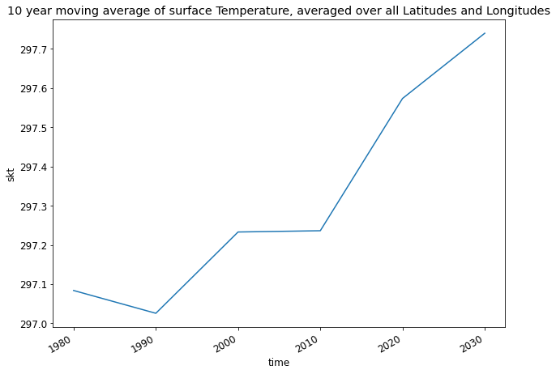

```python
ds_expver_1.resample({'time': '10y'}).mean(dim=['time', 'longitude', 'latitude']).skt.plot()
plt.title("10 year moving average of surface Temperature, averaged over all Latitudes and Longitudes")
```

# Merge and Concatenate Datasets

Extract the list of years, here 42 years have been considered

```python
ds_expver_1.groupby(ds_expver_1.time.dt.year).mean(dim = ['latitude', 'longitude', 'time']).year
```

```
<xarray.DataArray 'year' (year: 42)>
array([1979, 1980, 1981, 1982, 1983, 1984, 1985, 1986, 1987, 1988, 1989, 1990,
       1991, 1992, 1993, 1994, 1995, 1996, 1997, 1998, 1999, 2000, 2001, 2002,
       2003, 2004, 2005, 2006, 2007, 2008, 2009, 2010, 2011, 2012, 2013, 2014,
       2015, 2016, 2017, 2018, 2019, 2020], dtype=int64)
Coordinates:
    expver   int32 1
  * year     (year) int64 1979 1980 1981 1982 1983 ... 2016 2017 2018 2019 2020
```

Extract the values of years, corresponding to the monthly averaged values

```python
years = ds_expver_1.time.dt.year
```

# Merge the year array as a new variable to the older dataset

```python
print(ds)
```

```
<xarray.Dataset>
Dimensions:    (longitude: 142, latitude: 89, expver: 2, time: 500)
Coordinates:
  * longitude  (longitude) float32 -82.0 -81.75 -81.5 ... -47.25 -47.0 -46.75
  * latitude   (latitude) float32 6.0 5.75 5.5 5.25 ... -15.5 -15.75 -16.0
  * expver     (expver) int32 1 5
  * time       (time) datetime64[ns] 1979-01-01 1979-02-01 ... 2020-08-01
Data variables:
    lai_hv     (time, expver, latitude, longitude) float32 ...
    skt        (time, expver, latitude, longitude) float32 ...
    tp         (time, expver, latitude, longitude) float32 ...
Attributes:
    Conventions:  CF-1.6
    history:      2020-09-30 12:13:58 GMT by grib_to_netcdf-2.16.0: /opt/ecmw...
```

```python
ds_new = ds.merge(years)
```

```python
print(ds_new)
```

```
<xarray.Dataset>
Dimensions:    (longitude: 142, latitude: 89, expver: 2, time: 500)
Coordinates:
  * longitude  (longitude) float32 -82.0 -81.75 -81.5 ... -47.25 -47.0 -46.75
  * latitude   (latitude) float32 6.0 5.75 5.5 5.25 ... -15.5 -15.75 -16.0
  * expver     (expver) int32 1 5
  * time       (time) datetime64[ns] 1979-01-01 1979-02-01 ... 2020-08-01
Data variables:
    lai_hv     (time, expver, latitude, longitude) float32 ...
    skt        (time, expver, latitude, longitude) float32 ...
    tp         (time, expver, latitude, longitude) float32 ...
    year       (time) int64 1979 1979 1979 1979 1979 ... 2020 2020 2020 2020
Attributes:
    Conventions:  CF-1.6
    history:      2020-09-30 12:13:58 GMT by grib_to_netcdf-2.16.0: /opt/ecmw...
```

# Compute squared distance from Lat and Long and merge

```python
sq_dis = ds.latitude **2 + ds.longitude **2
sq_dis.name = "Squared Distance"
ds_new = ds_new.merge(sq_dis)
```

```python
print(ds_new)
```

```
<xarray.Dataset>
Dimensions:           (longitude: 142, latitude: 89, expver: 2, time: 500)
Coordinates:
  * longitude         (longitude) float32 -82.0 -81.75 -81.5 ... -47.0 -46.75
  * latitude          (latitude) float32 6.0 5.75 5.5 ... -15.5 -15.75 -16.0
  * expver            (expver) int32 1 5
  * time              (time) datetime64[ns] 1979-01-01 1979-02-01 ... 2020-08-01
Data variables:
    lai_hv            (time, expver, latitude, longitude) float32 ...
    skt               (time, expver, latitude, longitude) float32 ...
    tp                (time, expver, latitude, longitude) float32 ...
    year              (time) int64 1979 1979 1979 1979 ... 2020 2020 2020 2020
    Squared Distance  (latitude, longitude) float32 6.76e+03 ... 2.442e+03
Attributes:
    Conventions:  CF-1.6
    history:      2020-09-30 12:13:58 GMT by grib_to_netcdf-2.16.0: /opt/ecmw...
```

# Concatenate to add a new dimension

```python
ds_sq_root = ds_new ** (1/2)
ds_cube_root = ds_new ** (1/3)

ds_concat = xr.concat([ds_new, ds_sq_root, ds_cube_root], "Power_Dimension")
```

# Plot Total Precipitation of specific time step

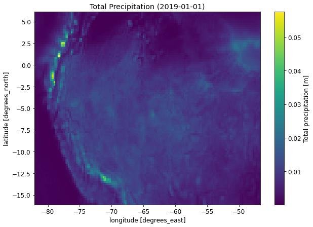

```python
ds_expver_1.sel(time = '2019-01-01').tp.plot()
plt.title("Total Precipitation (2019-01-01)")
```

# Select data from the newly created dimension and plot sq root and cubic root of precipitation

Plot sq root of precipitation

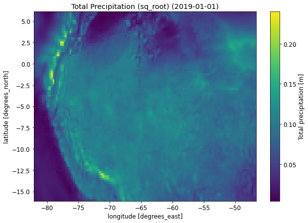

```python
ds_concat.sel(Power_Dimension = 1,time = '2019-01-01', expver =1).tp.plot()
plt.title("Total Precipitation (sq_root) (2019-01-01)")
```

Plot cubic root of precipitation

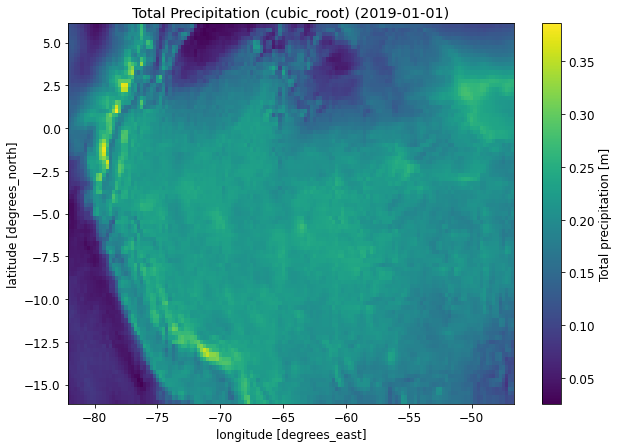

```python
ds_concat.sel(Power_Dimension = 2,time = '2019-01-01', expver =1).tp.plot()
plt.title("Total Precipitation (cubic_root) (2019-01-01)")
```

# Extract to DataFrame

```python
df = ds.to_dataframe()
```

```python
df
```

| longitude | latitude | expver | time | lai_hv | skt | tp |
| --- | --- | --- | --- | --- | --- | --- |
| -82.00 | 6.0 | 1 | 1979-01-01 | 0.000000 | 300.670105 | 0.000434 |
|  |  |  | 1979-02-01 | 0.000000 | 300.829926 | 0.001139 |
|  |  |  | 1979-03-01 | 0.000000 | 301.014832 | 0.005566 |
|  |  |  | 1979-04-01 | 0.000000 | 301.105957 | 0.011398 |
|  |  |  | 1979-05-01 | 0.000000 | 300.924347 | 0.009486 |
| ... | ... | ... | ... | ... | ... | ... |
| -46.75 | -16.0 | 5 | 2020-04-01 | NaN | NaN | NaN |
|  |  |  | 2020-05-01 | NaN | NaN | NaN |
|  |  |  | 2020-06-01 | NaN | NaN | NaN |
|  |  |  | 2020-07-01 | 1.452979 | 293.458069 | 0.000007 |
|  |  |  | 2020-08-01 | 1.402921 | 295.048279 | 0.000007 |

12638000 rows × 3 columns

# Export the months of the existing dataset to a dataframe

```python
months = ds.time.dt.month.to_dataframe()
```

```python
months
```

| time | month |
| --- | --- |
| 1979-01-01 | 1 |
| 1979-02-01 | 2 |
| 1979-03-01 | 3 |
| 1979-04-01 | 4 |
| 1979-05-01 | 5 |
| ... | ... |
| 2020-04-01 | 4 |
| 2020-05-01 | 5 |
| 2020-06-01 | 6 |
| 2020-07-01 | 7 |
| 2020-08-01 | 8 |

500 rows × 1 columns

# Xarray can also read from Pandas Dataframe and Series

# Export to netCDF is also possible